# INFO 659 Final Group Project

### **Group members:**

#### Alexandrea Morson

#### Lauren Tagliaferro

#### Maopin Yan

#### Nicole Buccigrossi

### **Date: 12/07/2021**

## Objective

To predict who will respond to an offer for a product or service.

## Data Source

The data is originally provided in XLSX format and was converted to CSV format.

It is available at: https://www.kaggle.com/rodsaldanha/arketing-campaign

### Read Data and data clean.

```r
library(ggplot2)
library(purrr)
library(tidyr)
library(caret)
library("e1071")
```

```r
cc <- read.csv("marketing_campaign.csv")
head(cc)
```

|  | ï..ID | Year_Birth | Education | Marital_Status | Income | Kidhome | Teenhome | Dt_Customer | Recency | MntWines | MntFruits | MntMeatProducts | MntFishProducts | MntSweetProducts | MntGoldProds | NumDealsPurchases | NumWebPurchases | NumCatalogPurchases | NumStorePurchases | NumWebVisitsMonth | AcceptedCmp3 | AcceptedCmp4 | AcceptedCmp5 | AcceptedCmp1 | AcceptedCmp2 | Complain | Z_CostContact | Z_Revenue | Response |
| --- | --- | --- | --- | --- | --- | --- | --- | --- | --- | --- | --- | --- | --- | --- | --- | --- | --- | --- | --- | --- | --- | --- | --- | --- | --- | --- | --- | --- | --- |
| 1 | 0 | 1985 | Graduation | Married | 70951 | 0 | 0 | 2013-05-04 | 66 | 239 | 10 | 554 | 254 | 87 | 54 | 1 | 3 | 4 | 9 | 1 | 0 | 0 | 0 | 0 | 0 | 0 | 3 | 11 | 0 |
| 2 | 1 | 1961 | Graduation | Single | 57091 | 0 | 0 | 2014-06-15 | 0 | 464 | 5 | 64 | 7 | 0 | 37 | 1 | 7 | 3 | 7 | 5 | 0 | 0 | 0 | 0 | 1 | 0 | 3 | 11 | 1 |
| 3 | 9 | 1975 | Master | Single | 46098 | 1 | 1 | 2012-08-18 | 86 | 57 | 0 | 27 | 0 | 0 | 36 | 4 | 3 | 2 | 2 | 8 | 0 | 0 | 0 | 0 | 0 | 0 | 3 | 11 | 0 |
| 4 | 13 | 1947 | PhD | Widow | 25358 | 0 | 1 | 2013-07-22 | 57 | 19 | 0 | 5 | 0 | 0 | 8 | 2 | 1 | 0 | 3 | 6 | 0 | 0 | 0 | 0 | 0 | 0 | 3 | 11 | 0 |
| 5 | 17 | 1971 | PhD | Married | 60491 | 0 | 1 | 2013-09-06 | 81 | 637 | 47 | 237 | 12 | 19 | 76 | 4 | 6 | 11 | 7 | 5 | 0 | 0 | 0 | 0 | 0 | 0 | 3 | 11 | 0 |
| 6 | 20 | 1965 | 2n Cycle | Married | 46891 | 0 | 1 | 2013-09-01 | 91 | 43 | 12 | 23 | 29 | 15 | 61 | 1 | 2 | 1 | 4 | 4 | 0 | 0 | 0 | 0 | 0 | 0 | 3 | 11 | 0 |

There are totally 29 variables and 2240 instances in this dataset. We found that there are 24 Nan values in the dataframe, we choose to drop those nan values as they are in a small amount. After we drop the nan values, there are 29 variables and 2216 rows.

```r
cc <- na.omit(cc)
dim(cc)
```

```
[1] 2216   29
```

### Data Transformation.

Transform the variables **AcceptedCmp1, AcceptedCmp2, AcceptedCmp3, AcceptedCmp4, AcceptedCmp5, Response, Complain** into a **categorical** (factor) variable (0 to “No”, 1 to “Yes”):

```r
cc$AcceptedCmp1 <- factor(cc$AcceptedCmp1,levels=c(0,1), labels=c("No","Yes"))

cc$AcceptedCmp2 <- factor(cc$AcceptedCmp2,levels=c(0,1), labels=c("No","Yes"))

cc$AcceptedCmp3 <- factor(cc$AcceptedCmp3,levels=c(0,1), labels=c("No","Yes"))

cc$AcceptedCmp4 <- factor(cc$AcceptedCmp4,levels=c(0,1), labels=c("No","Yes"))

cc$AcceptedCmp5 <- factor(cc$AcceptedCmp5,levels=c(0,1), labels=c("No","Yes"))

#cc$Response <- factor(cc$Response,levels=c(0,1), labels=c("No","Yes"))

cc$Complain <- factor(cc$Complain,levels=c(0,1), labels=c("No","Yes"))

head(cc)
```

|  | ï..ID | Year_Birth | Education | Marital_Status | Income | Kidhome | Teenhome | Dt_Customer | Recency | MntWines | MntFruits | MntMeatProducts | MntFishProducts | MntSweetProducts | MntGoldProds | NumDealsPurchases | NumWebPurchases | NumCatalogPurchases | NumStorePurchases | NumWebVisitsMonth | AcceptedCmp3 | AcceptedCmp4 | AcceptedCmp5 | AcceptedCmp1 | AcceptedCmp2 | Complain | Z_CostContact | Z_Revenue | Response |
| --- | --- | --- | --- | --- | --- | --- | --- | --- | --- | --- | --- | --- | --- | --- | --- | --- | --- | --- | --- | --- | --- | --- | --- | --- | --- | --- | --- | --- | --- |
| 1 | 0 | 1985 | Graduation | Married | 70951 | 0 | 0 | 2013-05-04 | 66 | 239 | 10 | 554 | 254 | 87 | 54 | 1 | 3 | 4 | 9 | 1 | No | No | No | No | No | No | 3 | 11 | 0 |
| 2 | 1 | 1961 | Graduation | Single | 57091 | 0 | 0 | 2014-06-15 | 0 | 464 | 5 | 64 | 7 | 0 | 37 | 1 | 7 | 3 | 7 | 5 | No | No | No | No | Yes | No | 3 | 11 | 1 |
| 3 | 9 | 1975 | Master | Single | 46098 | 1 | 1 | 2012-08-18 | 86 | 57 | 0 | 27 | 0 | 0 | 36 | 4 | 3 | 2 | 2 | 8 | No | No | No | No | No | No | 3 | 11 | 0 |
| 4 | 13 | 1947 | PhD | Widow | 25358 | 0 | 1 | 2013-07-22 | 57 | 19 | 0 | 5 | 0 | 0 | 8 | 2 | 1 | 0 | 3 | 6 | No | No | No | No | No | No | 3 | 11 | 0 |
| 5 | 17 | 1971 | PhD | Married | 60491 | 0 | 1 | 2013-09-06 | 81 | 637 | 47 | 237 | 12 | 19 | 76 | 4 | 6 | 11 | 7 | 5 | No | No | No | No | No | No | 3 | 11 | 0 |
| 6 | 20 | 1965 | 2n Cycle | Married | 46891 | 0 | 1 | 2013-09-01 | 91 | 43 | 12 | 23 | 29 | 15 | 61 | 1 | 2 | 1 | 4 | 4 | No | No | No | No | No | No | 3 | 11 | 0 |

### Plot histagrams about the relationship between Response and all the other variables.

**Response and Income. We found that with the increase of income, there is a higher probability of response “yes”.**

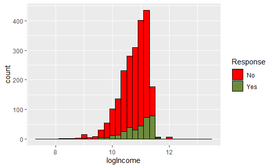

```r
cc$logIncome = log(cc$Income)
ggplot(cc, aes(x=logIncome, fill=Response, color=Response)) +
       geom_histogram(binwidth=0.2, position="stack", size = 0.5) +
       scale_color_manual(values=c("black","black")) +
       scale_fill_manual(values=c("red", "darkolivegreen4") )
```

```r
NA
NA
```

**Response and Kidhome.**

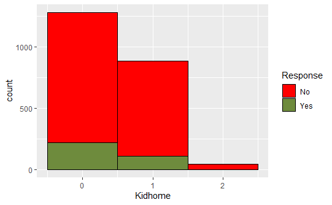

```r
ggplot(cc, aes(x=Kidhome, fill=Response, color=Response)) +
  geom_histogram(binwidth=1, position="stack") +
  scale_color_manual(values=c("black","black")) +
  scale_fill_manual(values=c("red", "darkolivegreen4"))
```

**Response and Teenhome**

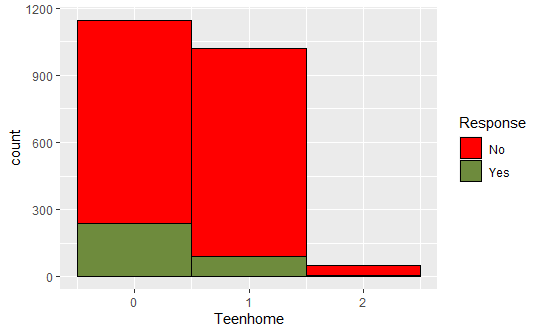

```r
ggplot(cc, aes(x=Teenhome, fill=Response, color=Response)) +
  geom_histogram(binwidth=1, position="stack") +
  scale_color_manual(values=c("black","black")) +
  scale_fill_manual(values=c("red", "darkolivegreen4"))
```

**Response and MntFishProducts**

```r
ggplot(cc, aes(x=MntFishProducts, fill=Response, color=Response)) +
  geom_histogram(binwidth=10, position="stack") +
  scale_color_manual(values=c("black","black")) +
  scale_fill_manual(values=c("red", "darkolivegreen4"))
```

[output not shown]

**Response and MntMeatProducts**

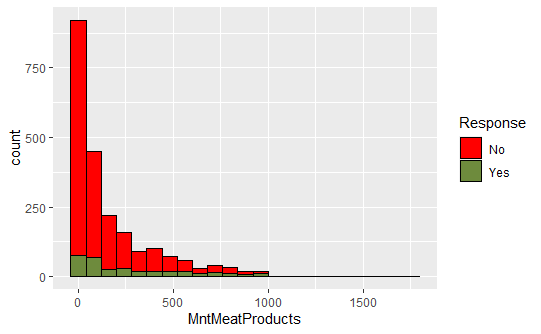

```r
ggplot(cc, aes(x=MntMeatProducts, fill=Response, color=Response)) +
  geom_histogram(binwidth=80, position="stack") +
  scale_color_manual(values=c("black","black")) +
  scale_fill_manual(values=c("red", "darkolivegreen4"))
```

From the histogram above we found that the more a household spent on meat products in the last 2 years, the higher probability of the “Yes” response.

**Response and MntFruits**

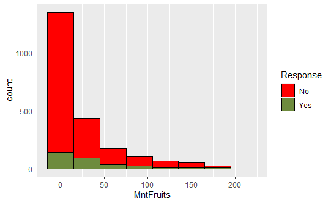

```r
ggplot(cc, aes(x=MntFruits, fill=Response, color=Response)) +
  geom_histogram(binwidth=30, position="stack") +
  scale_color_manual(values=c("black","black")) +
  scale_fill_manual(values=c("red", "darkolivegreen4"))
```

**Response and MntSweetProducts**

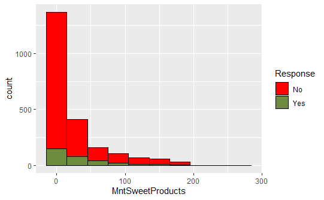

```r
ggplot(cc, aes(x=MntSweetProducts, fill=Response, color=Response)) +
  geom_histogram(binwidth=30, position="stack") +
  scale_color_manual(values=c("black","black")) +
  scale_fill_manual(values=c("red", "darkolivegreen4"))
```

**Response and MntWines**

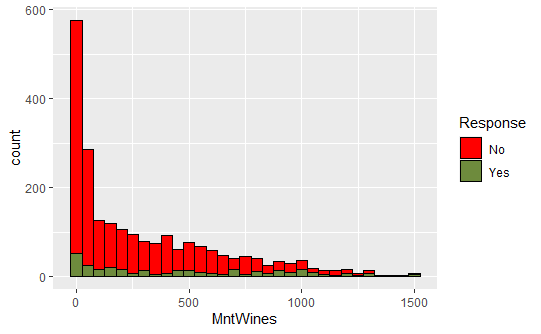

```r
ggplot(cc, aes(x=MntWines, fill=Response, color=Response)) +
  geom_histogram(binwidth=50, position="stack") +
  scale_color_manual(values=c("black","black")) +
  scale_fill_manual(values=c("red", "darkolivegreen4"))
```

From the histogram above we found that the more a household spent on wines in the last 2 years, the higher probability of the “Yes” response.

**Response and MntGoldProds**

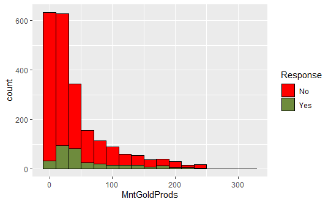

```r
ggplot(cc, aes(x=MntGoldProds, fill=Response, color=Response)) +
  geom_histogram(binwidth=20, position="stack") +
  scale_color_manual(values=c("black","black")) +
  scale_fill_manual(values=c("red", "darkolivegreen4"))
```

**Response and NumDealsPurchases**

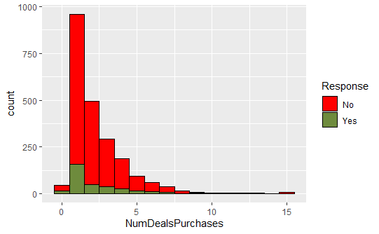

```r
ggplot(cc, aes(x=NumDealsPurchases, fill=Response, color=Response)) +
  geom_histogram(binwidth=1, position="stack") +
  scale_color_manual(values=c("black","black")) +
  scale_fill_manual(values=c("red", "darkolivegreen4"))
```

From the histogram above we found that when number of purchases made with discount equals to 1, the probability of Response of “Yes” will be high.

**Response and NumCatalogPurchases**

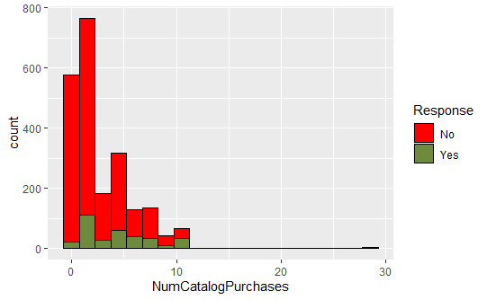

```r
ggplot(cc, aes(x=NumCatalogPurchases, fill=Response, color=Response)) +
  geom_histogram(binwidth=1.5, position="stack") +
  scale_color_manual(values=c("black","black")) +
  scale_fill_manual(values=c("red", "darkolivegreen4"))
```

**Response and NumStorePurchases**

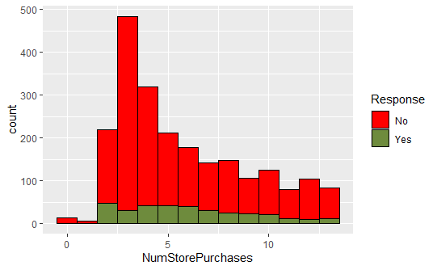

```r
ggplot(cc, aes(x=NumStorePurchases, fill=Response, color=Response)) +
  geom_histogram(binwidth=1, position="stack") +
  scale_color_manual(values=c("black","black")) +
  scale_fill_manual(values=c("red", "darkolivegreen4"))
```

**Response and NumWebPurchases**

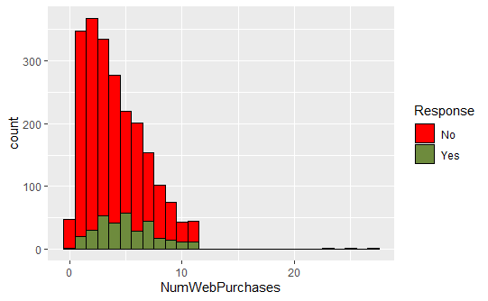

```r
ggplot(cc, aes(x=NumWebPurchases, fill=Response, color=Response)) +
  geom_histogram(binwidth=1, position="stack") +
  scale_color_manual(values=c("black","black")) +
  scale_fill_manual(values=c("red", "darkolivegreen4"))
```

From the histogram above we found that the probability of Response “Yes” is high when the number of purchases made through company’s web site is between 9 to 12.

**Response and NumWebVisitsMonth**

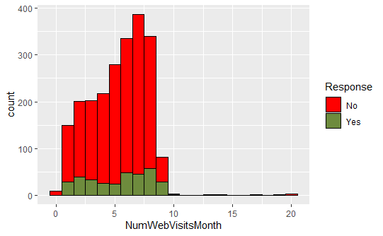

```r
ggplot(cc, aes(x=NumWebVisitsMonth, fill=Response, color=Response)) +
  geom_histogram(binwidth=1, position="stack") +
  scale_color_manual(values=c("black","black")) +
  scale_fill_manual(values=c("red", "darkolivegreen4"))
```

**Response and Recency**

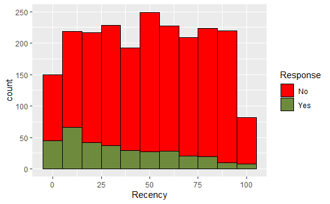

```r
ggplot(cc, aes(x=Recency, fill=Response, color=Response)) +
  geom_histogram(binwidth=10, position="stack") +
  scale_color_manual(values=c("black","black")) +
  scale_fill_manual(values=c("red", "darkolivegreen4"))
```

#### View all the variables’ distributions.

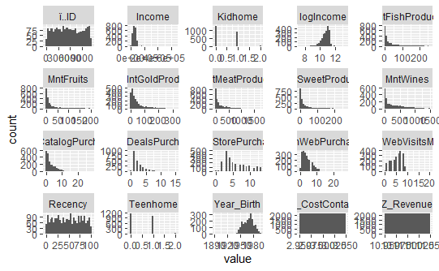

```r
cc %>%
  keep(is.numeric) %>%
  gather() %>%
  ggplot(aes(value)) +
    facet_wrap(~ key, scales = "free") +
    geom_histogram()
```

Through the above plots, we can see that most of the variables are right skewness distributed. So we will do the modeling part using the original variables as well as the variables after logarithm transformation, and find the best variables for modeling. The following code is the log transformation.

**Create a new dataframe (cc_new) and copy the original dataset.**

```r
cc_new = cc
head(cc_new)
```

|  | ï..ID | Year_Birth | Education | Marital_Status | Income | Kidhome | Teenhome | Dt_Customer | Recency | MntWines | MntFruits | MntMeatProducts | MntFishProducts | MntSweetProducts | MntGoldProds | NumDealsPurchases | NumWebPurchases | NumCatalogPurchases | NumStorePurchases | NumWebVisitsMonth | AcceptedCmp3 | AcceptedCmp4 | AcceptedCmp5 | AcceptedCmp1 | AcceptedCmp2 | Complain | Z_CostContact | Z_Revenue | Response | … |
| --- | --- | --- | --- | --- | --- | --- | --- | --- | --- | --- | --- | --- | --- | --- | --- | --- | --- | --- | --- | --- | --- | --- | --- | --- | --- | --- | --- | --- | --- | --- |
| 1 | 0 | 1985 | Graduation | Married | 70951 | 0 | 0 | 2013-05-04 | 66 | 239 | 10 | 554 | 254 | 87 | 54 | 1 | 3 | 4 | 9 | 1 | No | No | No | No | No | No | 3 | 11 | No | … |
| 2 | 1 | 1961 | Graduation | Single | 57091 | 0 | 0 | 2014-06-15 | 0 | 464 | 5 | 64 | 7 | 0 | 37 | 1 | 7 | 3 | 7 | 5 | No | No | No | No | Yes | No | 3 | 11 | Yes | … |
| 3 | 9 | 1975 | Master | Single | 46098 | 1 | 1 | 2012-08-18 | 86 | 57 | 0 | 27 | 0 | 0 | 36 | 4 | 3 | 2 | 2 | 8 | No | No | No | No | No | No | 3 | 11 | No | … |
| 4 | 13 | 1947 | PhD | Widow | 25358 | 0 | 1 | 2013-07-22 | 57 | 19 | 0 | 5 | 0 | 0 | 8 | 2 | 1 | 0 | 3 | 6 | No | No | No | No | No | No | 3 | 11 | No | … |
| 5 | 17 | 1971 | PhD | Married | 60491 | 0 | 1 | 2013-09-06 | 81 | 637 | 47 | 237 | 12 | 19 | 76 | 4 | 6 | 11 | 7 | 5 | No | No | No | No | No | No | 3 | 11 | No | … |
| 6 | 20 | 1965 | 2n Cycle | Married | 46891 | 0 | 1 | 2013-09-01 | 91 | 43 | 12 | 23 | 29 | 15 | 61 | 1 | 2 | 1 | 4 | 4 | No | No | No | No | No | No | 3 | 11 | No | … |

**Log transformation of some right skewness variables.**

```r
#cc_new$logIncome = log(cc_new$Income)
cc_new$logMntFishProducts = log(cc_new$MntFishProducts)
cc_new$logMntMeatProducts = log(cc_new$MntMeatProducts)
cc_new$logMntWines = log(cc_new$MntWines)
cc_new$logMntFruits = log(cc_new$MntFruits)

cc_new$logMntSweetProducts = log(cc_new$MntSweetProducts)
cc_new$logMntGoldProds = log(cc_new$MntGoldProds)
```

[output not shown]

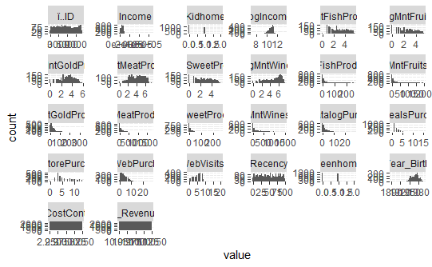

```r
cc_new %>%
  keep(is.numeric) %>%
  gather() %>%
  ggplot(aes(value)) +
    facet_wrap(~ key, scales = "free") +
    geom_histogram()
```

Drop original columns before logarithm.

```r
# drop original columns before logarithm.
cc_new = subset(cc_new, select = -c(Income, MntFishProducts, MntMeatProducts, MntWines, MntFruits, MntSweetProducts, MntGoldProds))
head(cc_new)
```

|  | ï..ID | Year_Birth | Education | Marital_Status | Kidhome | Teenhome | Dt_Customer | Recency | NumDealsPurchases | NumWebPurchases | NumCatalogPurchases | NumStorePurchases | NumWebVisitsMonth | AcceptedCmp3 | AcceptedCmp4 | AcceptedCmp5 | AcceptedCmp1 | AcceptedCmp2 | Complain | Z_CostContact | Z_Revenue | Response | logIncome | logMntFishProducts | logMntMeatProducts | logMntWines | logMntFruits | logMntSweetProducts | logMntGoldProds |
| --- | --- | --- | --- | --- | --- | --- | --- | --- | --- | --- | --- | --- | --- | --- | --- | --- | --- | --- | --- | --- | --- | --- | --- | --- | --- | --- | --- | --- | --- |
| 1 | 0 | 1985 | Graduation | Married | 0 | 0 | 2013-05-04 | 66 | 1 | 3 | 4 | 9 | 1 | No | No | No | No | No | No | 3 | 11 | No | 11.16974 | 5.537334 | 6.317165 | 5.476464 | 2.302585 | 4.465908 | 3.988984 |
| 2 | 1 | 1961 | Graduation | Single | 0 | 0 | 2014-06-15 | 0 | 1 | 7 | 3 | 7 | 5 | No | No | No | No | Yes | No | 3 | 11 | Yes | 10.95240 | 1.945910 | 4.158883 | 6.139885 | 1.609438 | -Inf | 3.610918 |
| 3 | 9 | 1975 | Master | Single | 1 | 1 | 2012-08-18 | 86 | 4 | 3 | 2 | 2 | 8 | No | No | No | No | No | No | 3 | 11 | No | 10.73852 | -Inf | 3.295837 | 4.043051 | -Inf | -Inf | 3.583519 |
| 4 | 13 | 1947 | PhD | Widow | 0 | 1 | 2013-07-22 | 57 | 2 | 1 | 0 | 3 | 6 | No | No | No | No | No | No | 3 | 11 | No | 10.14085 | -Inf | 1.609438 | 2.944439 | -Inf | -Inf | 2.079442 |
| 5 | 17 | 1971 | PhD | Married | 0 | 1 | 2013-09-06 | 81 | 4 | 6 | 11 | 7 | 5 | No | No | No | No | No | No | 3 | 11 | No | 11.01025 | 2.484907 | 5.468060 | 6.456770 | 3.850148 | 2.944439 | 4.330733 |
| 6 | 20 | 1965 | 2n Cycle | Married | 0 | 1 | 2013-09-01 | 91 | 1 | 2 | 1 | 4 | 4 | No | No | No | No | No | No | 3 | 11 | No | 10.75558 | 3.367296 | 3.135494 | 3.761200 | 2.484907 | 2.708050 | 4.110874 |

We found that there are some Inf values after log transformation. We are going to transform those Inf values to 1, and drop nan values.

```r
cc_new[cc_new == 'Inf'] <- 1

cc_new <- na.omit(cc_new)
dim(cc_new)
```

```
[1] 2216   29
```

```r
head(cc_new)
```

|  | ï..ID | Year_Birth | Education | Marital_Status | Kidhome | Teenhome | Dt_Customer | Recency | NumDealsPurchases | NumWebPurchases | NumCatalogPurchases | NumStorePurchases | NumWebVisitsMonth | AcceptedCmp3 | AcceptedCmp4 | AcceptedCmp5 | AcceptedCmp1 | AcceptedCmp2 | Complain | Z_CostContact | Z_Revenue | Response | logIncome | logMntFishProducts | logMntMeatProducts | logMntWines | logMntFruits | logMntSweetProducts | logMntGoldProds |
| --- | --- | --- | --- | --- | --- | --- | --- | --- | --- | --- | --- | --- | --- | --- | --- | --- | --- | --- | --- | --- | --- | --- | --- | --- | --- | --- | --- | --- | --- |
| 1 | 0 | 1985 | Graduation | Married | 0 | 0 | 2013-05-04 | 66 | 1 | 3 | 4 | 9 | 1 | No | No | No | No | No | No | 3 | 11 | No | 11.16974 | 5.537334 | 6.317165 | 5.476464 | 2.302585 | 4.465908 | 3.988984 |
| 2 | 1 | 1961 | Graduation | Single | 0 | 0 | 2014-06-15 | 0 | 1 | 7 | 3 | 7 | 5 | No | No | No | No | Yes | No | 3 | 11 | Yes | 10.95240 | 1.945910 | 4.158883 | 6.139885 | 1.609438 | -Inf | 3.610918 |
| 3 | 9 | 1975 | Master | Single | 1 | 1 | 2012-08-18 | 86 | 4 | 3 | 2 | 2 | 8 | No | No | No | No | No | No | 3 | 11 | No | 10.73852 | -Inf | 3.295837 | 4.043051 | -Inf | -Inf | 3.583519 |
| 4 | 13 | 1947 | PhD | Widow | 0 | 1 | 2013-07-22 | 57 | 2 | 1 | 0 | 3 | 6 | No | No | No | No | No | No | 3 | 11 | No | 10.14085 | -Inf | 1.609438 | 2.944439 | -Inf | -Inf | 2.079442 |
| 5 | 17 | 1971 | PhD | Married | 0 | 1 | 2013-09-06 | 81 | 4 | 6 | 11 | 7 | 5 | No | No | No | No | No | No | 3 | 11 | No | 11.01025 | 2.484907 | 5.468060 | 6.456770 | 3.850148 | 2.944439 | 4.330733 |
| 6 | 20 | 1965 | 2n Cycle | Married | 0 | 1 | 2013-09-01 | 91 | 1 | 2 | 1 | 4 | 4 | No | No | No | No | No | No | 3 | 11 | No | 10.75558 | 3.367296 | 3.135494 | 3.761200 | 2.484907 | 2.708050 | 4.110874 |

#### From the above data visualization, we got two dataset to do the modeling. One is the original dataset (cc), the second one is the dataset after logarithm transformation (cc_new).

**Models on the original dataset (cc). Models we used for this dataset are SVM and Logistic Regression Model.** **We are going to split the dataset, 80% for training dataset (Train_new), 20% for testing dataset (Test_new).**

```r
set.seed(0)
index_new<-createDataPartition(factor(cc$Response), p=0.8, list=F)

Train_new<-cc[index_new,]
nrow(Train_new)
```

```
[1] 1774
```

```r
Test_new<-cc[-index_new,]
nrow(Test_new)
```

```
[1] 442
```

To see whether the new parameters are in the dataset.

```r
head(Train_new)
```

|  | ï..ID | Year_Birth | Education | Marital_Status | Income | Kidhome | Teenhome | Dt_Customer | Recency | MntWines | MntFruits | MntMeatProducts | MntFishProducts | MntSweetProducts | MntGoldProds | NumDealsPurchases | NumWebPurchases | NumCatalogPurchases | NumStorePurchases | NumWebVisitsMonth | AcceptedCmp3 | AcceptedCmp4 | AcceptedCmp5 | AcceptedCmp1 | AcceptedCmp2 | Complain | Z_CostContact | Z_Revenue | Response |
| --- | --- | --- | --- | --- | --- | --- | --- | --- | --- | --- | --- | --- | --- | --- | --- | --- | --- | --- | --- | --- | --- | --- | --- | --- | --- | --- | --- | --- | --- |
| 1 | 0 | 1985 | Graduation | Married | 70951 | 0 | 0 | 2013-05-04 | 66 | 239 | 10 | 554 | 254 | 87 | 54 | 1 | 3 | 4 | 9 | 1 | No | No | No | No | No | No | 3 | 11 | 0 |
| 2 | 1 | 1961 | Graduation | Single | 57091 | 0 | 0 | 2014-06-15 | 0 | 464 | 5 | 64 | 7 | 0 | 37 | 1 | 7 | 3 | 7 | 5 | No | No | No | No | Yes | No | 3 | 11 | 1 |
| 4 | 13 | 1947 | PhD | Widow | 25358 | 0 | 1 | 2013-07-22 | 57 | 19 | 0 | 5 | 0 | 0 | 8 | 2 | 1 | 0 | 3 | 6 | No | No | No | No | No | No | 3 | 11 | 0 |
| 5 | 17 | 1971 | PhD | Married | 60491 | 0 | 1 | 2013-09-06 | 81 | 637 | 47 | 237 | 12 | 19 | 76 | 4 | 6 | 11 | 7 | 5 | No | No | No | No | No | No | 3 | 11 | 0 |
| 6 | 20 | 1965 | 2n Cycle | Married | 46891 | 0 | 1 | 2013-09-01 | 91 | 43 | 12 | 23 | 29 | 15 | 61 | 1 | 2 | 1 | 4 | 4 | No | No | No | No | No | No | 3 | 11 | 0 |
| 8 | 24 | 1960 | Master | Together | 17144 | 1 | 1 | 2014-02-15 | 96 | 18 | 2 | 19 | 0 | 2 | 6 | 5 | 3 | 0 | 4 | 7 | No | No | No | No | No | No | 3 | 11 | 0 |

### Model 1: SVM on the original dataset.

**We are going to try how SVM classifier trained on the dataset without features selection. We are going to try cost = 1, and gamma = 0.5 on this model.**

```r
svm_model <- svm(Response ~ Income+Kidhome+ Teenhome+ Recency+ MntWines+ MntFruits+ MntMeatProducts+ MntFishProducts+ MntSweetProducts+ MntGoldProds+ NumDealsPurchases+ NumWebPurchases+ NumCatalogPurchases+ NumStorePurchases+ NumWebVisitsMonth+ Z_CostContact+ Z_Revenue, Train_new, kernel="radial", cost=1, gamma=0.5)
summary(svm_model)
```

```
Call:
svm(formula = Response ~ Income + Kidhome + Teenhome + Recency + MntWines + MntFruits + MntMeatProducts +
    MntFishProducts + MntSweetProducts + MntGoldProds + NumDealsPurchases + NumWebPurchases + NumCatalogPurchases +
    NumStorePurchases + NumWebVisitsMonth + Z_CostContact + Z_Revenue, data = Train_new, kernel = "radial",
    cost = 1, gamma = 0.5)


Parameters:
   SVM-Type:  C-classification
 SVM-Kernel:  radial
       cost:  1

Number of Support Vectors:  1667

 ( 1400 267 )


Number of Classes:  2

Levels:
 No Yes
```

See the Confusion Matrix of the original datase under SVM model.

```r
confusionMatrix(prediction, Test_new$Response, dnn = c("Prediction", "Truth"))
```

```
Confusion Matrix and Statistics

          Truth
Prediction  No Yes
       No  373  58
       Yes   3   8

               Accuracy : 0.862
                 95% CI : (0.8263, 0.8928)
    No Information Rate : 0.8507
    P-Value [Acc > NIR] : 0.2774

                  Kappa : 0.1725

 Mcnemar's Test P-Value : 4.712e-12

            Sensitivity : 0.9920
            Specificity : 0.1212
         Pos Pred Value : 0.8654
         Neg Pred Value : 0.7273
             Prevalence : 0.8507
         Detection Rate : 0.8439
   Detection Prevalence : 0.9751
      Balanced Accuracy : 0.5566

       'Positive' Class : No
```

### Model 2: Logistic Regression Model on the original dataset.

**The next step is, we are going to use logistic regression model to train on the dataset.**

We will train the Train_new dataset use all the features, and comparing the confusion matrix out with the new dataset after features selection.

**Apply logistic regresion model on the original dataset.**

```r
default_lr_model_all <- glm(Response ~ Income+Kidhome+ Teenhome+ Recency+ MntWines+ MntFruits+ MntMeatProducts+ MntFishProducts+ MntSweetProducts+ MntGoldProds+ NumDealsPurchases+ NumWebPurchases+ NumCatalogPurchases+ NumStorePurchases+ NumWebVisitsMonth+ Z_CostContact+ Z_Revenue, data = Train_new, family = "binomial")

summary(default_lr_model_all)
```

```
Call:
glm(formula = Response ~ Income + Kidhome + Teenhome + Recency +
    MntWines + MntFruits + MntMeatProducts + MntFishProducts +
    MntSweetProducts + MntGoldProds + NumDealsPurchases + NumWebPurchases +
    NumCatalogPurchases + NumStorePurchases + NumWebVisitsMonth +
    Z_CostContact + Z_Revenue, family = "binomial", data = Train_new)

Deviance Residuals:
    Min       1Q   Median       3Q      Max
-2.8880  -0.5386  -0.3424  -0.1910   2.8490

Coefficients: (2 not defined because of singularities)
                      Estimate Std. Error z value Pr(>|z|)
(Intercept)         -2.493e+00  4.129e-01  -6.038 1.56e-09 ***
Income               2.182e-06  2.954e-06   0.739  0.46014
Kidhome              1.706e-01  2.081e-01   0.820  0.41247
Teenhome            -1.039e+00  1.939e-01  -5.357 8.47e-08 ***
Recency             -2.548e-02  2.826e-03  -9.015  < 2e-16 ***
MntWines             1.490e-03  2.993e-04   4.978 6.43e-07 ***
MntFruits           -4.874e-04  2.244e-03  -0.217  0.82801
MntMeatProducts      1.969e-03  4.934e-04   3.991 6.58e-05 ***
MntFishProducts     -1.610e-03  1.697e-03  -0.949  0.34262
MntSweetProducts     1.774e-03  2.124e-03   0.835  0.40346
MntGoldProds         3.140e-03  1.478e-03   2.124  0.03365 *
NumDealsPurchases    5.981e-02  4.783e-02   1.250  0.21117
NumWebPurchases      1.028e-01  3.356e-02   3.062  0.00220 **
NumCatalogPurchases  1.086e-01  3.933e-02   2.763  0.00573 **
NumStorePurchases   -1.680e-01  3.278e-02  -5.124 3.00e-07 ***
NumWebVisitsMonth    1.940e-01  4.520e-02   4.292 1.77e-05 ***
Z_CostContact               NA         NA      NA       NA
Z_Revenue                   NA         NA      NA       NA
---
Signif. codes:  0 ‘***’ 0.001 ‘**’ 0.01 ‘*’ 0.05 ‘.’ 0.1 ‘ ’ 1

(Dispersion parameter for binomial family taken to be 1)

    Null deviance: 1502.9  on 1773  degrees of freedom
Residual deviance: 1177.9  on 1758  degrees of freedom
AIC: 1209.9

Number of Fisher Scoring iterations: 6
```

```r
pred_lr_all <- predict(default_lr_model_all, newdata = Test_new, type = "response")
class(pred_lr_all)
```

```
[1] "numeric"
```

```r
pred_lr_class_all <- ifelse(pred_lr_all >= 0.3, 1, 0)
class(pred_lr_class_all)
```

```
[1] "numeric"
```

```r
result_table_all <- table(pred_lr_class_all, Test_new$Response)
result_table_all
```

```
pred_lr_class_all   0   1
                0 339  33
                1  37  33
```

```r
results <- confusionMatrix(data=factor(pred_lr_class_all, levels=0:1),reference = factor(Test_new$Response, levels=0:1), positive = "1")
print(results)
```

```
Confusion Matrix and Statistics

          Reference
Prediction   0   1
         0 339  33
         1  37  33

               Accuracy : 0.8416
                 95% CI : (0.8042, 0.8744)
    No Information Rate : 0.8507
    P-Value [Acc > NIR] : 0.7292

                  Kappa : 0.3918

 Mcnemar's Test P-Value : 0.7199

            Sensitivity : 0.50000
            Specificity : 0.90160
         Pos Pred Value : 0.47143
         Neg Pred Value : 0.91129
             Prevalence : 0.14932
         Detection Rate : 0.07466
   Detection Prevalence : 0.15837
      Balanced Accuracy : 0.70080

       'Positive' Class : 1
```

### Model 3: We do the logistic Regression model based on the selected features.

**We will select 7 features with the lowest p-values: Teenhome, Recency, MntWines, MntMeatProducts, NumStorePurchases, NumWebVisitsMonth, NumWebPurchases. And use the logistic model train on the new dataset.**

```r
default_lr_model <- glm(Response ~ Teenhome+ Recency+ MntWines+ MntMeatProducts+ NumWebPurchases+ NumStorePurchases+ NumWebVisitsMonth, data = Train_new, family = "binomial")

summary(default_lr_model)
```

```
Call:
glm(formula = Response ~ Teenhome + Recency + MntWines + MntMeatProducts +
    NumWebPurchases + NumStorePurchases + NumWebVisitsMonth,
    family = "binomial", data = Train_new)

Deviance Residuals:
    Min       1Q   Median       3Q      Max
-2.1745  -0.5456  -0.3563  -0.2063   2.9797

Coefficients:
                    Estimate Std. Error z value Pr(>|z|)
(Intercept)       -2.0536937  0.3370393  -6.093 1.11e-09 ***
Teenhome          -0.8818513  0.1676194  -5.261 1.43e-07 ***
Recency           -0.0245962  0.0027872  -8.825  < 2e-16 ***
MntWines           0.0017111  0.0002782   6.150 7.76e-10 ***
MntMeatProducts    0.0025841  0.0004233   6.105 1.03e-09 ***
NumWebPurchases    0.1315644  0.0317325   4.146 3.38e-05 ***
NumStorePurchases -0.1662288  0.0321964  -5.163 2.43e-07 ***
NumWebVisitsMonth  0.1796937  0.0388932   4.620 3.83e-06 ***
---
Signif. codes:  0 ‘***’ 0.001 ‘**’ 0.01 ‘*’ 0.05 ‘.’ 0.1 ‘ ’ 1

(Dispersion parameter for binomial family taken to be 1)

    Null deviance: 1502.9  on 1773  degrees of freedom
Residual deviance: 1197.7  on 1766  degrees of freedom
AIC: 1213.7

Number of Fisher Scoring iterations: 5
```

```r
pred_lr <- predict(default_lr_model, newdata = Test_new, type = "response")
class(pred_lr)
```

```
[1] "numeric"
```

We decrease pred_lr from 0.5 to 0.3 to increase the precision and recall value.

```r
pred_lr_class <- ifelse(pred_lr >= 0.3, 1, 0)
class(pred_lr_class)
```

```
[1] "numeric"
```

```r
result_table <- table(pred_lr_class, Test_new$Response)
result_table
```

```
pred_lr_class   0   1
            0 344  39
            1  32  27
```

Confusion matrix for 7 selected features. Results are even worse than the model 2.

```r
results <- confusionMatrix(data=factor(pred_lr_class, levels=0:1),reference = factor(Test_new$Response, levels=0:1), positive = "1")
print(results)
```

```
Confusion Matrix and Statistics

          Reference
Prediction   0   1
         0 344  39
         1  32  27

               Accuracy : 0.8394
                 95% CI : (0.8018, 0.8724)
    No Information Rate : 0.8507
    P-Value [Acc > NIR] : 0.7707

                  Kappa : 0.3388

 Mcnemar's Test P-Value : 0.4764

            Sensitivity : 0.40909
            Specificity : 0.91489
         Pos Pred Value : 0.45763
         Neg Pred Value : 0.89817
             Prevalence : 0.14932
         Detection Rate : 0.06109
   Detection Prevalence : 0.13348
      Balanced Accuracy : 0.66199

       'Positive' Class : 1
```

### Model 4: SVM for the new dataset (cc_new), which is after log transformation.

For log transformation, there are some Inf and -Inf values. Then we do the transformation from Inf to 1, and -Inf to 0 (as 0 is the smallest value in the columns).

```r
cc_new[cc_new == 'Inf'] <- 1
cc_new[cc_new == '-Inf'] <- 0
cc_new[is.na(cc_new)] <- 1
View(cc_new)
```

We split the new dataset(dataset after log transformation) into 80% for training, and 20% for testing.

```r
set.seed(0)
index_log<-createDataPartition(factor(cc_new$Response), p=0.8, list=F)

Train_log<-cc_new[index_log,]
nrow(Train_log)
```

```
[1] 1774
```

```r
Test_log<-cc_new[-index_log,]
nrow(Test_log)
```

```
[1] 442
```

**We are going to try how SVM classifier trained on the dataset(cc_new) without features selection. We are going to try cost = 1, and gamma = 0.5 on this model.**

```r
library("e1071")
svm_model_log <- svm(Response ~ Kidhome + Teenhome + Recency+ NumDealsPurchases +NumWebPurchases + NumCatalogPurchases + NumStorePurchases + NumWebVisitsMonth + logMntFishProducts+logMntMeatProducts+logMntWines + logMntFruits + logMntSweetProducts + logMntGoldProds, Train_log, kernel="radial", cost=1, gamma=0.5)
summary(svm_model_log)
```

```
Call:
svm(formula = Response ~ Kidhome + Teenhome + Recency + NumDealsPurchases + NumWebPurchases + NumCatalogPurchases +
    NumStorePurchases + NumWebVisitsMonth + logMntFishProducts + logMntMeatProducts + logMntWines + logMntFruits +
    logMntSweetProducts + logMntGoldProds, data = Train_log, kernel = "radial", cost = 1, gamma = 0.5)


Parameters:
   SVM-Type:  C-classification
 SVM-Kernel:  radial
       cost:  1

Number of Support Vectors:  1192

 ( 929 263 )


Number of Classes:  2

Levels:
 No Yes
```

```r
prediction_log <- predict (svm_model_log, Test_log)
confusionMatrix(prediction_log, Test_log$Response, dnn = c("Prediction", "Truth"))
```

```
Confusion Matrix and Statistics

          Truth
Prediction  No Yes
       No  369  55
       Yes   7  11

               Accuracy : 0.8597
                 95% CI : (0.8238, 0.8907)
    No Information Rate : 0.8507
    P-Value [Acc > NIR] : 0.3246

                  Kappa : 0.2114

 Mcnemar's Test P-Value : 2.387e-09

            Sensitivity : 0.9814
            Specificity : 0.1667
         Pos Pred Value : 0.8703
         Neg Pred Value : 0.6111
             Prevalence : 0.8507
         Detection Rate : 0.8348
   Detection Prevalence : 0.9593
      Balanced Accuracy : 0.5740

       'Positive' Class : No
```

### Results

Below is the Evaluation Results of Different Models.

[figure not shown]

Evaluation Metrics for the 4 models.